# A4_Tessmann_Meag

Meag Tessmann

2/24/2020

# Ch1: Setup

A. Load packages and import data. Set stringsAsFactors = TRUE. Create a data frame including all variables.

B. Partition the dataset for a simple hold-out evaluation: 70% for training and 30% for testing.

```r
knitr::opts_chunk$set(echo = TRUE)

#############
##### A #####
#############

library(caret) # data partitioning
library(RWeka) # model training
library(kernlab) # svm training
library(rminer) # model training
library(matrixStats) # metrics + stats
library(skimr) # data preview
library(knitr) # fancy tables
library(tidyverse) # data manipulation
library(kableExtra) # fancy tables
# load data with factors, preview data
churn <- read.csv('churn2.csv', stringsAsFactors = TRUE)
skim(churn)
```

```
## Skim summary statistics
##  n obs: 12611
##  n variables: 12
##
## ── Variable type:factor ───────────────────────────────────────────────
##                    variable missing complete     n n_unique
##                     COLLEGE       0    12611 12611        2
##  CONSIDERING_CHANGE_OF_PLAN       0    12611 12611        5
##                       LEAVE       0    12611 12611        2
##       REPORTED_SATISFACTION       0    12611 12611        5
##        REPORTED_USAGE_LEVEL       0    12611 12611        5
##                                  top_counts ordered
##                 zer: 6325, one: 6286, NA: 0   FALSE
##   con: 5049, act: 3134, no: 2508, nev: 1288   FALSE
##                STA: 10148, LEA: 2463, NA: 0   FALSE
##  ver: 4917, ver: 3226, uns: 2482, avg: 1315   FALSE
##  lit: 4970, ver: 3226, ver: 2516, hig: 1270   FALSE
##
## ── Variable type:integer ──────────────────────────────────────────────
##                     variable missing complete     n      mean        sd     p0
##        AVERAGE_CALL_DURATION       0    12611 12611      6.02      4.32      1
##                HANDSET_PRICE       0    12611 12611    378.55    208.75    130
##                        HOUSE       0    12611 12611 524519.53 260315.44 150015
##                       INCOME       0    12611 12611  78016.7   40884.86  20007
##                     LEFTOVER       0    12611 12611     22.89     26.02      0
##  OVER_15MINS_CALLS_PER_MONTH       0    12611 12611      6.9       8.41      0
##                      OVERAGE       0    12611 12611     74.19     82.49     -2
##       p25   p50      p75   p100     hist
##       2       5      9       15 ▇▃▆▁▁▂▂▂
##     216     318    497.5    899 ▇▆▆▂▂▂▂▂
##  274914   5e+05 752823.5  1e+06 ▇▆▃▃▃▅▃▅
##   41339.5 72180 111069   159983 ▇▇▅▅▅▃▃▃
##       0      14     36       89 ▇▃▂▁▁▁▁▁
##       1       4     11       29 ▇▃▁▁▁▁▁▁
##       0      53    155      301 ▇▅▁▁▂▂▁▁
```

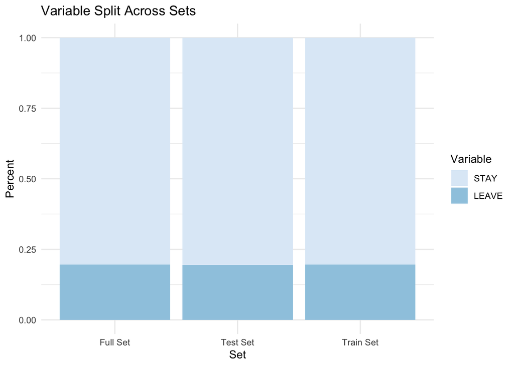

```r
#############
##### B #####
#############

# Create test/train partitions with 70% training
set.seed(500)
inTrain <- createDataPartition(y=churn$LEAVE, p=0.70, list=FALSE)

# Create sets, using partitioning index from ln 48
train <- churn[inTrain, ]
test <- churn[-inTrain, ]

# Check target variable distribution
splits_target <- as.matrix(rbind(
  prop.table(table(train$LEAVE)),
  prop.table(table(test$LEAVE)),
  prop.table(table(churn$LEAVE))
))

splits_target <- as.data.frame(splits_target)
splits_target$Set <- c("Train Set", "Test Set", "Full Set")

splits_target %>%
  gather(set, Percent, LEAVE:STAY) %>%
  ggplot(aes(x=Set, y=Percent, fill=forcats::fct_rev(set))) +
  geom_bar(stat="identity") +
  scale_fill_brewer() +
  theme_minimal() +
  labs(title = "Variable Split Across Sets", x = "Set", y = "Percent", fill = "Variable")
```

```r
  # geom_label("Target")
```

# Ch2: Default Neural Net

Build and evaluate a neural network (MLP) model using a simple hold-out evaluation. Use the same classification performance metrics as in Assignment 2.

A. Build an MLP model using the training set with MultilayerPerceptron()’s default setting.

B. Generate the model’s evaluation metrics using the training and test sets, separately.

> *Observations*  
> Seems to be overfitting - precision drops from 62 to 48 (training to test) - over half of the the test set’s positive predictions are wrongly classified. It’s ability to correctly classify LEAVE is slightly concerning - true positive rates in the 20s and 30s seem low.

```r
#############
##### A #####
#############

metrics_list <- c("ACC", "TPR", "PRECISION", "F1")

# create shorthand for superlong name
MLP <- make_Weka_classifier("weka/classifiers/functions/MultilayerPerceptron")


# MLP's default parameter values of MLP,L=0.3,M=0.2, N=500,H='a'
# L: learning rate with default=0.3
# M: momemtum with default=0.2
# N: number of epochs with default=500
# H: number of nodes in each layer (numbers separated by commas)
  # The number of hidden nodes in each layer is one of the following:
  # an integer, or the letter 'a' = (attribs + classes) / 2,
  # 'i' = attribs, 'o' = classes, 't' = attribs .+ classes)
  # Default = 'a'.

# start with default values
l <- 0.3
m <- 0.2
n <- 500
h <- 'a'

# train model with defaults, view summaries
model_mlp1 <- MLP(LEAVE ~ . , data = train, control= Weka_control(L=l, M=m, N=n, H=h))
model_mlp1
```

```
## Sigmoid Node 0
##     Inputs    Weights
##     Threshold    0.8704841745598185
##     Node 2    -0.8628755387011752
##     Node 3    -1.837235819146194
##     Node 4    -1.5494136140448256
##     Node 5    -1.8029863282865273
##     Node 6    -1.3627385690689806
##     Node 7    -1.8886131965089898
##     Node 8    -1.2119788098432864
##     Node 9    -0.5683782399682789
##     Node 10    -2.4331401424121237
##     Node 11    -4.072547727121554
##     Node 12    -1.336842158918006
##     Node 13    -2.0995253301799033
## Sigmoid Node 1
##     Inputs    Weights
##     Threshold    -0.8704841745598184
##     Node 2    0.8628755387011753
##     Node 3    1.8372358191461944
##     Node 4    1.5494136140448262
##     Node 5    1.8029863282865273
##     Node 6    1.3627385690689806
##     Node 7    1.8886131965089878
##     Node 8    1.2119788098432858
##     Node 9    0.568378239968279
##     Node 10    2.4331401424121224
##     Node 11    4.072547727121555
##     Node 12    1.3368421589180057
##     Node 13    2.0995253301799024
## Sigmoid Node 2
##     Inputs    Weights
##     Threshold    -2.7541280476636163
##     Attrib COLLEGE=zero    3.210165114959113
##     Attrib INCOME    4.512692061629182
##     Attrib OVERAGE    -24.165999353351765
##     Attrib LEFTOVER    -18.233295641327896
##     Attrib HOUSE    0.31590984822822615
##     Attrib HANDSET_PRICE    3.3133413171208805
##     Attrib OVER_15MINS_CALLS_PER_MONTH    -6.107992928288931
```

[output cut: 293 more lines]

```
##     Attrib REPORTED_USAGE_LEVEL=high    15.103847793966738
##     Attrib REPORTED_USAGE_LEVEL=little    -2.1124802455069567
##     Attrib REPORTED_USAGE_LEVEL=very_high    -0.2551904792585156
##     Attrib REPORTED_USAGE_LEVEL=very_little    -1.0581940191409127
##     Attrib CONSIDERING_CHANGE_OF_PLAN=actively_looking_into_it    5.767651181128758
##     Attrib CONSIDERING_CHANGE_OF_PLAN=considering    -6.231534546549435
##     Attrib CONSIDERING_CHANGE_OF_PLAN=never_thought    3.226583921212431
##     Attrib CONSIDERING_CHANGE_OF_PLAN=no    1.2569237210235107
##     Attrib CONSIDERING_CHANGE_OF_PLAN=perhaps    8.575336539354026
## Class LEAVE
##     Input
##     Node 0
## Class STAY
##     Input
##     Node 1
```

```r
summary(model_mlp1)
```

```
##
## === Summary ===
##
## Correctly Classified Instances        7335               83.0785 %
## Incorrectly Classified Instances      1494               16.9215 %
## Kappa statistic                          0.3524
## Mean absolute error                      0.25
## Root mean squared error                  0.3578
## Relative absolute error                 79.5168 %
## Root relative squared error             90.2328 %
## Total Number of Instances             8829
##
## === Confusion Matrix ===
##
##     a    b   <-- classified as
##   593 1132 |    a = LEAVE
##   362 6742 |    b = STAY
```

```r
#############
##### B #####
#############

# predict on test and train sets
predict_mlp1_test <- predict(model_mlp1, test)
predict_mlp1_train <- predict(model_mlp1, train)

# create matrix to make pretty table of metrics for each set
stats_mpl1 <- as.matrix(rbind(
  mmetric(train$LEAVE, predict_mlp1_train, metric=metrics_list),
  mmetric(test$LEAVE, predict_mlp1_test, metric=metrics_list)
))
rownames(stats_mpl1) <- c("Train Set", "Test Set")


# make pretty table f
knitr::kable(stats_mpl1, digits=2) %>% kable_styling(bootstrap_options = c("hover"))
```

|  | ACC | TPR1 | TPR2 | PRECISION1 | PRECISION2 | F11 | F12 |
| --- | --- | --- | --- | --- | --- | --- | --- |
| Train Set | 83.08 | 34.38 | 94.90 | 62.09 | 85.62 | 44.25 | 90.03 |
| Test Set | 80.25 | 24.80 | 93.69 | 48.80 | 83.71 | 32.88 | 88.42 |

```r
# Seems to be overfitting - precision drops from 62 to 48 (training to test) - over half of the the test set's positive predictions are wrongly classified. It's ability to correctly classify LEAVE is slightly concerning - true positive rates in the 20s and 30s seem low.

# checking frquency of target variable - it's 19.5%
NROW(which(churn$LEAVE=="LEAVE"))/NROW(churn)
```

```
## [1] 0.1953057
```

# Ch3: Support Vector Machine

Build and evaluate SVM (ksvm) models using a simple hold-out evaluation. Use the same classification performance metrics as in Assignment 2.

A. Build a ksvm model using the training set with ksvm()’s default setting. Generate the model’s evaluation metrics using the training and test sets, separately.

B. Build a ksvm model using the training set with kernel = “polydot”. Use C=10 for the cost. Generate the model’s evaluation metrics using the training and test sets, separately.

> *Observations*  
> *Default Model*: This model is terrible at classifying LEAVE and seems to be overfitting worse than the previous model. The true positive rate for LEAVE dropped significantly compared to the last model. This time precision drops from 74 to 48. It did improve in correctly classifying STAY, though.  
> *Polydot with Cost 10 Model*: This seems weird, but it’s classifying everything as STAY? This is basically a majority class model. I’m guessing this is generalizing too much.

```r
#############
##### A #####
#############

# train default svm model, view summaries
model_svm1 <- ksvm(LEAVE ~., data = train)
model_svm1
```

```
## Support Vector Machine object of class "ksvm"
##
## SV type: C-svc  (classification)
##  parameter : cost C = 1
##
## Gaussian Radial Basis kernel function.
##  Hyperparameter : sigma =  0.075383017775574
##
## Number of Support Vectors : 4072
##
## Objective Function Value : -3385.647
## Training error : 0.190735
```

```r
summary(model_svm1)
```

```
## Length  Class   Mode
##      1   ksvm     S4
```

```r
# predict on test/train set
predict_svm1_test <- predict(model_svm1, test)
predict_svm1_train <- predict(model_svm1, train)

# create matrix and put in pretty table
stats_svm1 <- as.matrix(rbind(
  mmetric(train$LEAVE, predict_svm1_train, metric=metrics_list),
  mmetric(test$LEAVE, predict_svm1_test, metric=metrics_list)
))
rownames(stats_svm1) <- c("Train Set", "Test Set")

knitr::kable(stats_svm1, digits=2) %>% kable_styling(bootstrap_options = c("hover"))
```

|  | ACC | TPR1 | TPR2 | PRECISION1 | PRECISION2 | F11 | F12 |
| --- | --- | --- | --- | --- | --- | --- | --- |
| Train Set | 80.93 | 3.65 | 99.69 | 74.12 | 80.99 | 6.96 | 89.37 |
| Test Set | 80.46 | 1.90 | 99.51 | 48.28 | 80.71 | 3.65 | 89.13 |

```r
# This model is terrible at classifying LEAVE and seems to be overfitting worse than the previous model. The true positive rate for LEAVE dropped significantly compared to the last model. This time precision drops from 74 to 48. It did improve in correctly classifying STAY, though.


#############
##### B #####
#############


# train svm model using polynomial kernal and cost set to 10, view summaries
model_svm_poly <- ksvm(LEAVE ~., data = train, kernel = 'polydot', C=10)
model_svm_poly
```

```
## Support Vector Machine object of class "ksvm"
##
## SV type: C-svc  (classification)
##  parameter : cost C = 10
##
## Polynomial kernel function.
##  Hyperparameters : degree =  1  scale =  1  offset =  1
##
## Number of Support Vectors : 4941
##
## Objective Function Value : -34500.01
## Training error : 0.195379
```

```r
summary(model_svm_poly)
```

```
## Length  Class   Mode
##      1   ksvm     S4
```

```r
# predict on test/train set
predict_svm_poly_test <- predict(model_svm_poly, test)
predict_svm_poly_train <- predict(model_svm_poly, train)

# create matrix and put in pretty table
stats_svm_poly <- as.matrix(rbind(
  mmetric(train$LEAVE, predict_svm_poly_train, metric=metrics_list),
  mmetric(test$LEAVE, predict_svm_poly_test, metric=metrics_list)
))
rownames(stats_svm_poly) <- c("Train Set", "Test Set")

knitr::kable(stats_svm_poly, digits=2) %>% kable_styling(bootstrap_options = c("hover"))
```

|  | ACC | TPR1 | TPR2 | PRECISION1 | PRECISION2 | F11 | F12 |
| --- | --- | --- | --- | --- | --- | --- | --- |
| Train Set | 80.46 | 0 | 100 | 0 | 80.46 | 0 | 89.17 |
| Test Set | 80.49 | 0 | 100 | 0 | 80.49 | 0 | 89.19 |

```r
# This seems weird, but it's classifying everything as STAY?

# Confirming with confusion matrix
mmetric(test$LEAVE, predict_svm_poly_test, metric="CONF")
```

```
## $res
## NULL
##
## $conf
##        pred
## target  LEAVE STAY
##   LEAVE     0  738
##   STAY      0 3044
##
## $roc
## NULL
##
## $lift
## NULL
```